# Clinical Data Science Analysis of MIMIC-III

Aashna Kothari

2026-01-16

Connection to google BigQuery

[output not shown]

[output not shown]

[output not shown]

[output not shown]

[output not shown]

## Admissions Dataset Overview

The admissions dataset has **129 observations** and **19 variables**, capturing “every unique hospitalization for each patient in the database”

Admissions Dataset

| ROW_ID | SUBJECT_ID | HADM_ID | ADMITTIME | DISCHTIME | DEATHTIME | ADMISSION_TYPE | ADMISSION_LOCATION | DISCHARGE_LOCATION | INSURANCE | LANGUAGE | RELIGION | MARITAL_STATUS | ETHNICITY | EDREGTIME | EDOUTTIME | DIAGNOSIS | HOSPITAL_EXPIRE_FLAG | HAS_CHARTEVENTS_DATA |
| --- | --- | --- | --- | --- | --- | --- | --- | --- | --- | --- | --- | --- | --- | --- | --- | --- | --- | --- |
| 12293 | 10043 | 168674 | 2185-04-14 00:23:00 | 2185-04-26 18:20:00 | NA | EMERGENCY | EMERGENCY ROOM ADMIT | SNF | Medicare | NA | CATHOLIC | NA | WHITE | 2185-04-13 23:01:00 | 2185-04-14 02:56:00 | RESPIRATORY DISTRESS | 0 | 1 |
| 12345 | 10094 | 168074 | 2180-02-29 18:54:00 | 2180-03-10 17:35:00 | NA | EMERGENCY | EMERGENCY ROOM ADMIT | SNF | Medicare | NA | UNOBTAINABLE | NA | BLACK/AFRICAN AMERICAN | 2180-02-29 12:40:00 | 2180-02-29 21:53:00 | HYPOTENSION;TELEMETRY | 0 | 1 |
| 12346 | 10094 | 122928 | 2180-03-15 22:35:00 | 2180-03-20 18:00:00 | 2180-03-20 18:00:00 | EMERGENCY | EMERGENCY ROOM ADMIT | DEAD/EXPIRED | Medicare | NA | UNOBTAINABLE | NA | BLACK/AFRICAN AMERICAN | 2180-03-15 17:14:00 | 2180-03-16 00:58:00 | SEPSIS;TELEMETRY | 1 | 1 |
| 12317 | 10067 | 160442 | 2130-10-06 01:34:00 | 2130-10-06 02:29:00 | 2130-10-06 02:29:00 | EMERGENCY | EMERGENCY ROOM ADMIT | DEAD/EXPIRED | Private | NA | UNOBTAINABLE | NA | OTHER | 2130-10-06 00:12:00 | 2130-10-06 01:30:00 | S/P MOTORCYCLE ACCIDENT | 1 | 1 |
| 12349 | 10098 | 180685 | 2170-12-02 23:24:00 | 2170-12-03 15:55:00 | 2170-12-03 15:55:00 | EMERGENCY | EMERGENCY ROOM ADMIT | DEAD/EXPIRED | Private | NA | UNOBTAINABLE | NA | OTHER | 2170-12-02 22:45:00 | 2170-12-03 00:56:00 | STATUS POST MOTOR VEHICLE ACCIDENT WITH INJURIES | 1 | 1 |
| 12265 | 10013 | 165520 | 2125-10-04 23:36:00 | 2125-10-07 15:13:00 | 2125-10-07 15:13:00 | EMERGENCY | TRANSFER FROM HOSP/EXTRAM | DEAD/EXPIRED | Medicare | NA | CATHOLIC | NA | UNKNOWN/NOT SPECIFIED | NA | NA | SEPSIS | 1 | 1 |
| 12340 | 10089 | 190301 | 2132-08-05 18:48:00 | 2132-08-08 02:15:00 | 2132-08-08 02:15:00 | EMERGENCY | EMERGENCY ROOM ADMIT | DEAD/EXPIRED | Medicare | NA | UNOBTAINABLE | NA | WHITE | 2132-08-05 14:38:00 | 2132-08-05 22:07:00 | BASAL GANGLIN BLEED | 1 | 1 |
| 12319 | 10069 | 146672 | 2188-02-08 11:15:00 | 2188-02-27 18:41:00 | 2188-02-27 18:41:00 | EMERGENCY | EMERGENCY ROOM ADMIT | DEAD/EXPIRED | Medicaid | NA | NA | NA | UNKNOWN/NOT SPECIFIED | 2188-02-07 15:50:00 | 2188-02-08 12:00:00 | SEIZURE | 1 | 1 |
| 40554 | 42430 | 100969 | 2142-11-26 21:20:00 | 2142-11-30 10:55:00 | 2142-11-30 10:55:00 | EMERGENCY | EMERGENCY ROOM ADMIT | DEAD/EXPIRED | Medicare | ENGL | CHRISTIAN SCIENTIST | NA | WHITE | 2142-11-26 18:08:00 | 2142-11-26 22:18:00 | CEREBROVASCULAR ACCIDENT | 1 | 1 |
| 12314 | 10064 | 111761 | 2127-03-19 14:39:00 | 2127-03-19 18:09:00 | 2127-03-19 18:09:00 | EMERGENCY | EMERGENCY ROOM ADMIT | DEAD/EXPIRED | Medicare | NA | UNOBTAINABLE | NA | WHITE | 2127-03-19 12:54:00 | 2127-03-19 15:39:00 | SUBDURAL HEMATOMA/S/P FALL | 1 | 1 |

## Analyzing the ethnicities of the ICU admitted patients

| ETHNICITY |
| --- |
| WHITE |
| BLACK/AFRICAN AMERICAN |
| OTHER |
| UNKNOWN/NOT SPECIFIED |
| HISPANIC OR LATINO |
| HISPANIC/LATINO - PUERTO RICAN |
| ASIAN |
| AMERICAN INDIAN/ALASKA NATIVE FEDERALLY RECOGNIZED TRIBE |
| UNABLE TO OBTAIN |

As you can see, there are 9 distinct ethnicities present in this dataset. Let’s explore the distribution of patient ethnicities in order to bettter understand the demographic composition of ICU patients.

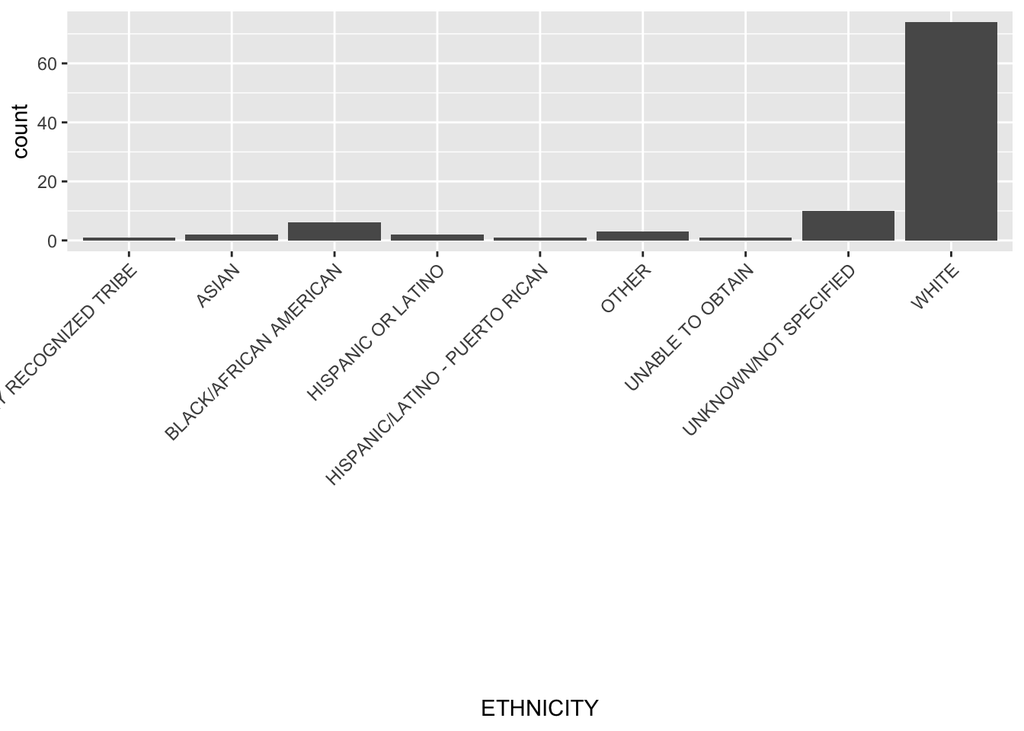

| ETHNICITY | count |
| --- | --- |
| BLACK/AFRICAN AMERICAN | 6 |
| UNKNOWN/NOT SPECIFIED | 10 |
| WHITE | 74 |
| OTHER | 3 |
| ASIAN | 2 |
| HISPANIC OR LATINO | 2 |
| HISPANIC/LATINO - PUERTO RICAN | 1 |
| UNABLE TO OBTAIN | 1 |
| AMERICAN INDIAN/ALASKA NATIVE FEDERALLY RECOGNIZED TRIBE | 1 |

## Exploring other variables including insurance, admission & discharge location

| INSURANCE |
| --- |
| Medicare |
| Private |
| Medicaid |
| Government |

| INSURANCE | count |
| --- | --- |
| Medicare | 76 |
| Private | 19 |
| Medicaid | 4 |
| Government | 1 |

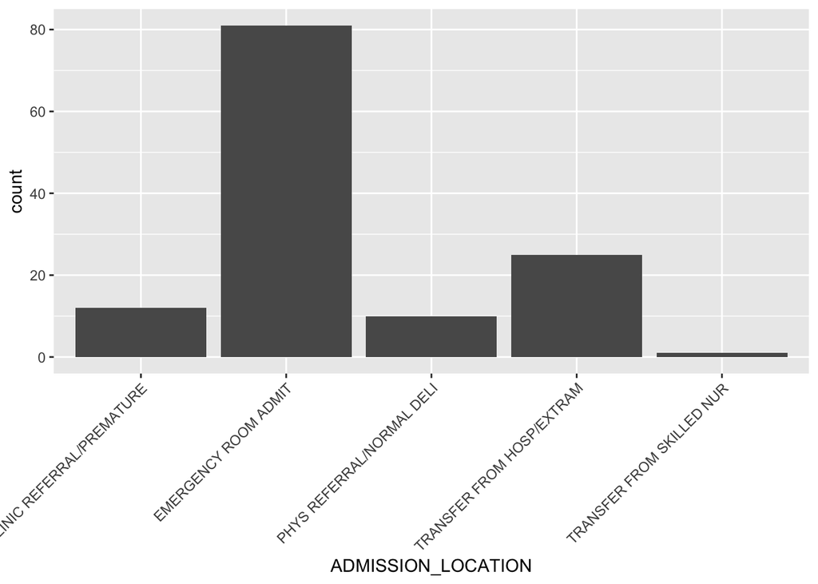

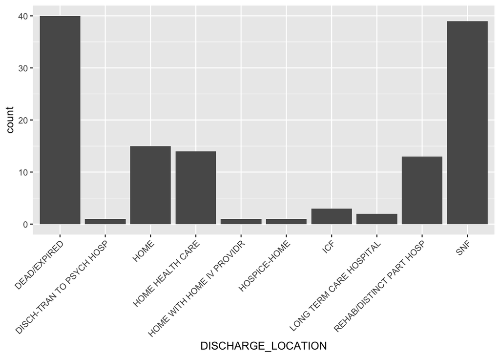

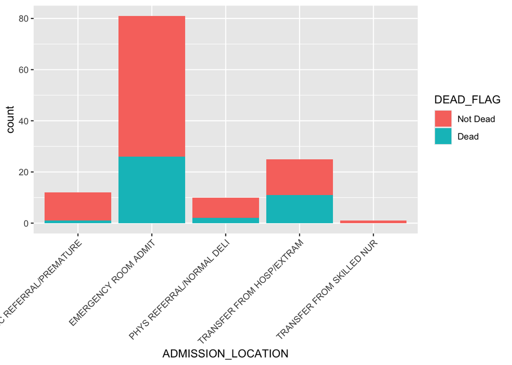

Since most of the patients admitted to this hospital were on medicare, it is evident that this dataset consists heavily of an aged, elderly white population. This intuitively makes sense as elderly patients tend to be in critical health conditions (ICU), and MIMIC contains ICU patient data.

Looking at the bar graph for admission locations, it is evident that most patients were emergency room admits, followed by transfer from hospital. Looking at the bar graph for discharge location, we can see that most patients died in the ICU unit they were admitted into or were moved into senior nursing facility upon discharge.

Stacked bar plot shows relationship between admission location and death.

## Let’s now get a comprehensive picture of ICD-9 diagnoses.

| LONG_TITLE |
| --- |
| Primary pulmonary hypertension |
| Atrial fibrillation |
| Acute systolic heart failure |
| Coronary atherosclerosis of native coronary artery |
| Mitral valve insufficiency and aortic valve stenosis |
| Congestive heart failure, unspecified |
| Cardiac complications, not elsewhere classified |
| Malignant essential hypertension |
| Anemia, unspecified |
| Urinary tract infection, site not specified |

[output cut: 551 more lines]

| ICD9_CODE | count |
| --- | --- |
| 4019 | 53 |
| 42731 | 48 |
| 5849 | 45 |
| 4280 | 39 |
| 51881 | 31 |
| 25000 | 31 |
| 2724 | 29 |
| 5990 | 27 |
| 486 | 26 |
| 2859 | 25 |

[output cut: 551 more lines]

| ROW_ID | ICD9_CODE | SHORT_TITLE | LONG_TITLE |
| --- | --- | --- | --- |
| 4304 | 4019 | Hypertension NOS | Unspecified essential hypertension |

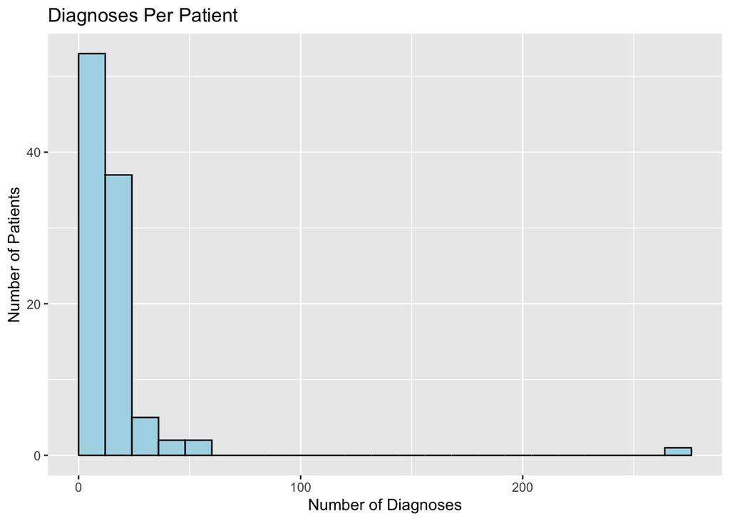

Analyzing microbiology events table

| SPEC_TYPE_DESC |
| --- |
| MRSA SCREEN |
| URINE |
| BLOOD CULTURE |
| STOOL |
| CATHETER TIP-IV |
| SPUTUM |
| Rapid Respiratory Viral Screen & Culture |
| IMMUNOLOGY |
| FLUID RECEIVED IN BLOOD CULTURE BOTTLES |
| BLOOD CULTURE ( MYCO/F LYTIC BOTTLE) |

[output cut: 24 more lines]

| SPEC_TYPE_DESC | count |
| --- | --- |
| BLOOD CULTURE | 559 |
| URINE | 508 |
| SPUTUM | 464 |
| SWAB | 104 |
| MRSA SCREEN | 87 |
| STOOL | 66 |
| Mini-BAL | 33 |
| CATHETER TIP-IV | 29 |
| BLOOD CULTURE ( MYCO/F LYTIC BOTTLE) | 28 |
| BRONCHOALVEOLAR LAVAGE | 23 |

[output cut: 24 more lines]

| SUBJECT_ID | HOSPITAL_EXPIRE_FLAG |
| --- | --- |
| 40310 | 1 |
| 40310 | 0 |
| 41976 | 0 |
| 41976 | 0 |
| 41976 | 0 |
| 41976 | 0 |
| 41976 | 0 |
| 41976 | 0 |
| 41976 | 0 |
| 41976 | 0 |

[output cut: 8 more lines]

Blood was the most commonly collected specimen, followed by urine. Patient 41976 had the most specimens collected overall (360) followed by patient 41914 with 122, and then 40310. Let’s check if these patients died during their ICU stay at this hospital? 40310 died.

## Let’s look the relationship between ICU Length of Stay (los) and in-hospital mortality

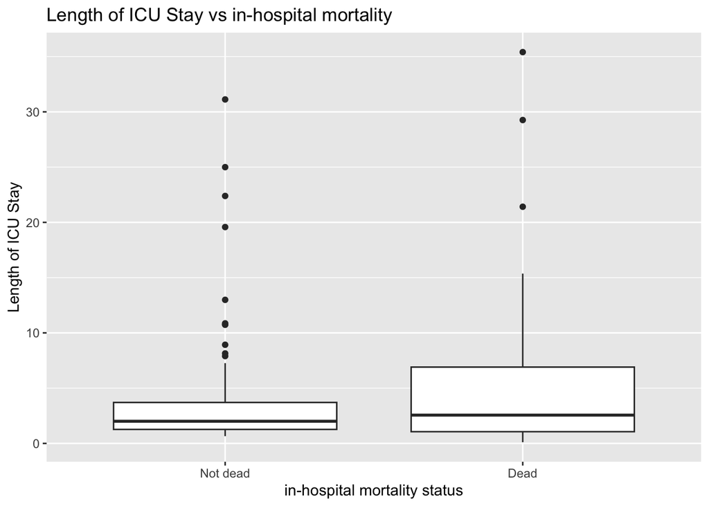